# Predicting Initial Unemployment Insurance Claims Using Google Trends

Paul Goldsmith-Pinkham, Elizabeth Pancotti, and Aaron Sojourner

May 2020

Many thanks to Dylan Piatt and Zach Swaziek for their help with this. Feedback always welcome at asojourn@umn.edu.

Data+code are available here: https://docs.google.com/spreadsheets/d/1RN1XJLIpU12QUwMpkF0DNiV8fkeqdHbWHta2sRfEZT4/edit#gid=651560 and https://github.com/paulgp/GoogleTrendsUINowcast

# Abstract

# Introduction

Understanding changes in national and state-level initial unemployment insurance (UI) claims have value to markets, policymakers, economists, journalists, and the public, especially in times of rapid labor-market deterioriation. Initial UI claims measure the number of Americans filing new claims for UI benefits. The weekly report from the U.S. Department of Labor (DOL) reporting initial UI claims nationally and by state is one of the most-sensitive, high-frequency, official statistics used to detect negative changes in the economy. Rising layoffs are an important, early part of recession. Companies do not report layoffs to the government in real time but, when employees get laid off, they have a strong incentive to immediately file for UI benefits, providing a quick signal to governments all over the nation. The DOL gathers, aggregates, and harmonizes information on initial claims from each state’s UI agency and reports each Thursday morning on activity during the prior Sunday-to-Saturday week, which started 11 days and ended 5 days earlier. The weekly national UI claims report expresses these negative changes well in advance of the Bureau of Economic Analysis’s quarterly GDP report, the Bureau of Labor Statistics’s survey-based monthly job report, or other sources. Most weeks, the UI report boringly resembles the week before and doesn’t make news. However, when the economy starting turning down, the UI claims report often delivers the first systematic signals. Wall Street analysts try to predict the DOL initial UI claims report every week because of its ability to deliver market-moving information.

This paper reports our efforts to nowcast initial UI claims at the state and national level in advance of the official report by leveraging an even more-immediate signal that strongly correlates with workers’ UI-claiming behavior, changes in search interest in the phrase “file for unemployment” on Google Trends. Before workers contact a state UI agency, many now conduct an internet search to learn about the process or to pull up the relevant agency phone number, address, or website. Google Trends reports a measure of change in search interest in any particular topic at the state-day level usually with a lag of only 1 to 3 days.[^1] Each Thursday, when DOL first reports on the prior week, our model can forecast the *current* week based on search activity in the early part of the week and some extrapolation.

A key innovation of the model is its attention to data at the daily level. Previously, Askitas and Zimmermann (2009) showed that monthly search activity for unemployment benefits and unemployment rates (different than initial UI claims) were correlated in German provinces. In the U.S., Choi and Varian (2012) predicted national-level weekly initial UI claims with a moving average of Google Trends search interest. Getting below weekly data hasn’t been possible in the U.S. until recently because very few states reported daily UI data before mid-March 2020. Coincident with the record-shattering surge in claims during the week ending March 21 (WE0321), many more states started reporting daily counts through *ad hoc* statements to the press or on their websites. During that week, we could find at least one news report or official statement about the number of new UI claims on a set of consecutive days from 35 states and the District of Columbia. We extrapolated these out to the full set of days in the week to estimate state UI claim growth rates relative to the prior 4 weeks. Analysis revealed little difference in search-intensity growth between states where we found reports and the others so we extrapolated out to the full set of states based on the observed average growth rate. This pre-cursor model predicted 3.3 million initial claims for the week without seasonal adjustment (SA) or 3.7 million with SA.[^2] The typical Wall Street prediction was 1.7 million (SA) and Goldman Sachs’s prediction of 2.3 million was viewed as surprisingly high.[^3]. The DOL report turned out to be 3.3 million (SA). Subsequently, we refined the data collection and modeling procedures into what’s reported here.

# Data Sources

## Initial UI claims

We measure the number of initial claims by state and day by coding any information available from news reports and state websites starting March 15. We gather and harmonize the various reported numbers across articles to construct a dataset of “reports.” News articles report fact statements that tend to describe the number of claims for a given set of consecutive dates based on information from state officials. For example, an article might say, the State received 10,394 claims on Monday and Tuesday. Since reports vary over what periods that they report data (some report over a four-day span, others over a one-day span), we reconcile these differences by using a “report-level” dataset, wherein each reported fact statement is treated as an observation. For each report, we construct the per-day average claim, and call that our daily claim measure. For estimation, we will link this to the average of the daily Google Trends data for that particular spell. We found at least one post-March 15 report for all 50 states and the District of Columbia (D.C.).[^4]

As a baseline for each state, we also measure average daily claims across the four weeks ending Saturdays from February 22 to March 14 from the official weekly data. Then, for any later day, we construct a growth rate $C_{sd}$ as the ratio of reported daily claims over the state’s baseline daily average. For validation exercises, we use official state-week and national-week advance reports.[^5]

## Search intensity of “File for unemployment”

To measure seach intensity, we pull data from Google Trends, a Google product that aggregates search volume by geography and time.[^6] Many papers have used Google Trends to measure search activity. Stephens-Davidowitz (2014) is a promenient example. The level of search interest reported from any query is normalized within that query such that the highest value reported equals 100 and other values in the query, such as in a different time, time-geography, or term-time-geography are reported relative to that. According to Google,

> Search results are normalized to the time and location of a query by the following process: Each data point is divided by the total searches of the geography and time range it represents to compare relative popularity. Otherwise, places with the most search volume would always be ranked highest. The resulting numbers are then scaled on a range of 0 to 100 based on a topic’s proportion to all searches on all topics.

More specifically, Stephens-Davidowitz says that Google Trends,

> … takes the percent of all searches that use that term; then divides by the highest number. So if 1 percent of searches include coronavirus in City A and 0.5 percent of searches include coronavirus in City B, city B will have a number half as high as City A.

We pull a dataset of all states and D.C., as well as the national trend (“USA”), collecting an index of the relative search volume for “file for unemployment.” This term is chosen to narrow in on the process a worker would follow to file for unemployment insurance. A more-general term, such as “unemployment”, “unemployment insurance,” or “unemployment benefits,” could be contiminated by search activity by people seeking news about the broad phenomenon rather than engaged in the process.

The search-intensity index data has three, non-obvious properties that demand special care. First, Google Trends only allows comparison of five locations per query. To elide this issue, we repeatedly pull data for California plus other four states, and continuously renormalize each state-$s$ by $\max{Index_{s}}/\max{Index_{CA}}$. This way, California becomes the numeraire and all states’ activity are measured relative to California so comparisons can be made both across time and geographies. We pull data from February 1st forward. Second, to protect privacy in cells with relatively-little search intensity, Google rounds small cells down to zero. In some smaller states, Google Trends reports search activity in the baseline period as zero. This would cause problems when using a growth measure based on a ratio, so we use a difference instead. Third, pulled values are based on a sample of search activity. Each time the query is made, pulled values can differ. To manage this, we pull each query multiple times and average across them.

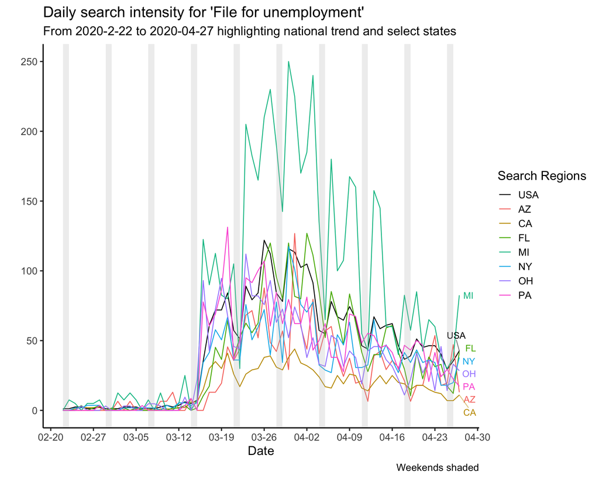

# Estimation

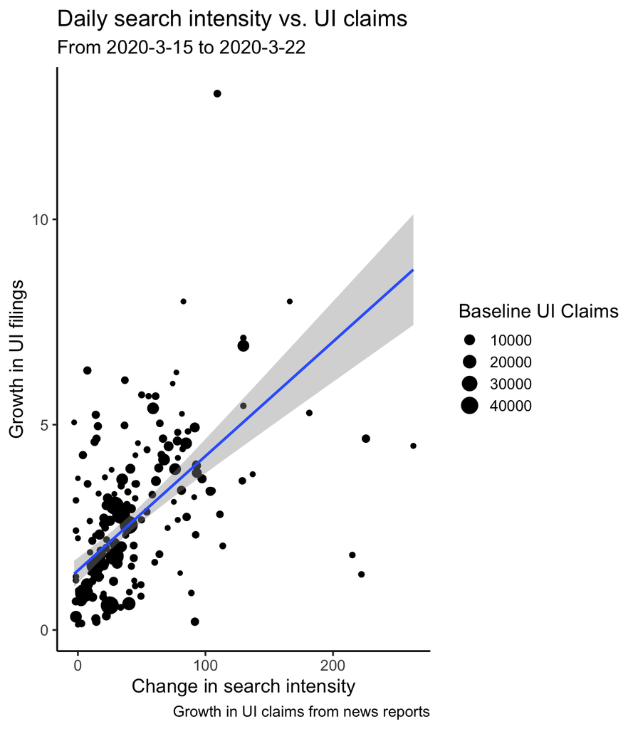

```
##
## Call:
## lm(formula = ui_norm ~ hits_norm, data = report_UI_GT_data %>%
##     filter(epiweek(week_end) <= 13), weights = baseline_ui)
##
## Weighted Residuals:
##     Min      1Q  Median      3Q     Max
## -356.20  -48.34    5.34   54.62  467.00
##
## Coefficients:
##             Estimate Std. Error t value Pr(>|t|)
## (Intercept) 1.465867   0.153487    9.55   <2e-16 ***
## hits_norm   0.032814   0.002835   11.57   <2e-16 ***
## ---
## Signif. codes:  0 '***' 0.001 '**' 0.01 '*' 0.05 '.' 0.1 ' ' 1
##
## Residual standard error: 112 on 249 degrees of freedom
## Multiple R-squared:  0.3498, Adjusted R-squared:  0.3471
## F-statistic: 133.9 on 1 and 249 DF,  p-value: < 2.2e-16
```

## In-sample validation

Finally, we forecast the single statistic of weekly national initial claims in a very straightforward way. The model predicts the level of UI growth based on the daily search-intensity data, which is then converted into predicted UI claims levels by mutliplying times the state’s baseline claims level. The predicted national claims level is just the sum of predicted UI claims levels across states for a week. To obtain a seasonally-adjusted prediction, we scale the national prediction by the DOL’s pre-announced, week-specific SA factor.

For WE0321, the model predicted 4.6 million UI claims, with a 95% CI of 4.1 million and 5 million.

For the week of 3/15-3/21, there are initial advance reports of UI claims at the state level that reported on March 26. We compare the model’s predictions for that week relative to the advance numbers, and find that for many states the model did quite well. However, for certain states, particularly California and New York, it was substantially over. This discrepancy may be due to overwhelm of UI administrative systems in those states.

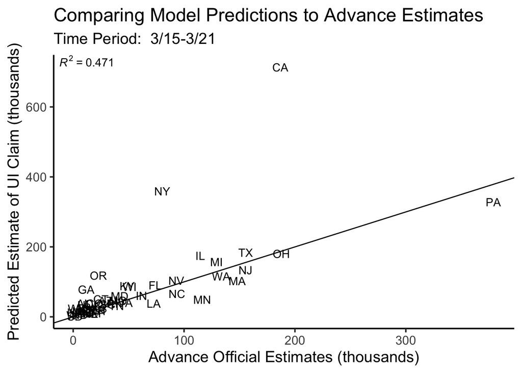

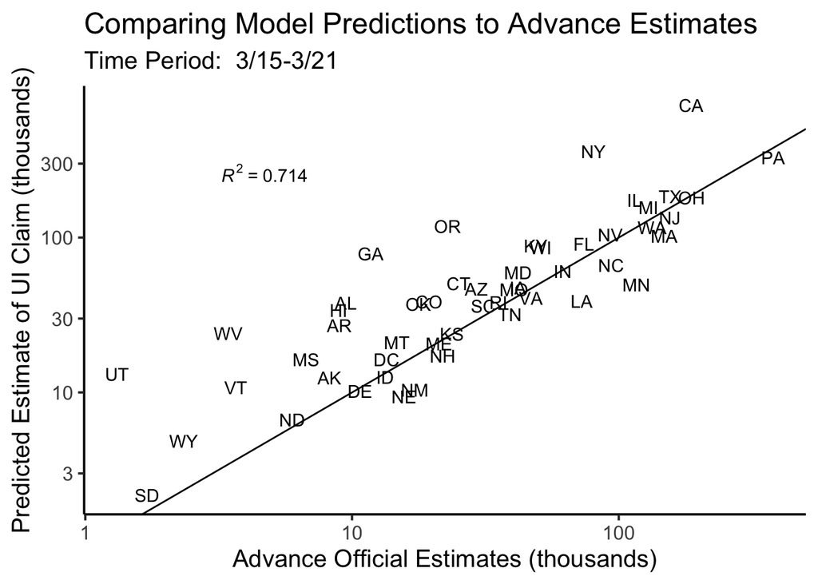

We can also look at the *revised* numbers reported on April 2nd and see how we do relative to those:

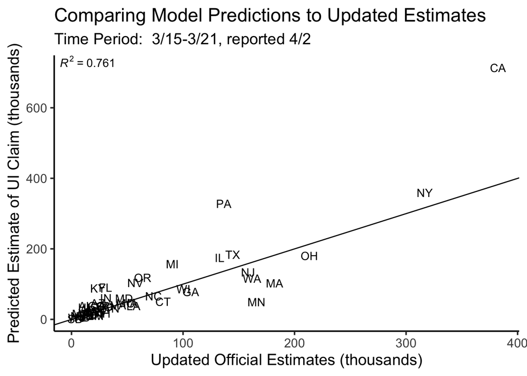

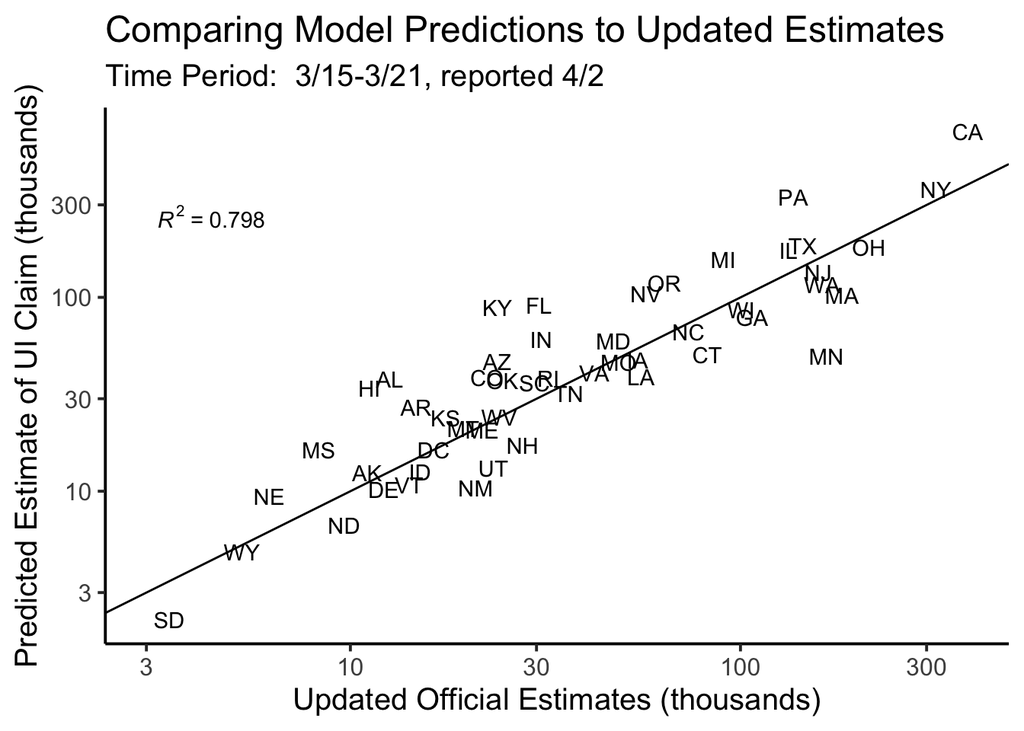

## Out-of-sample validation

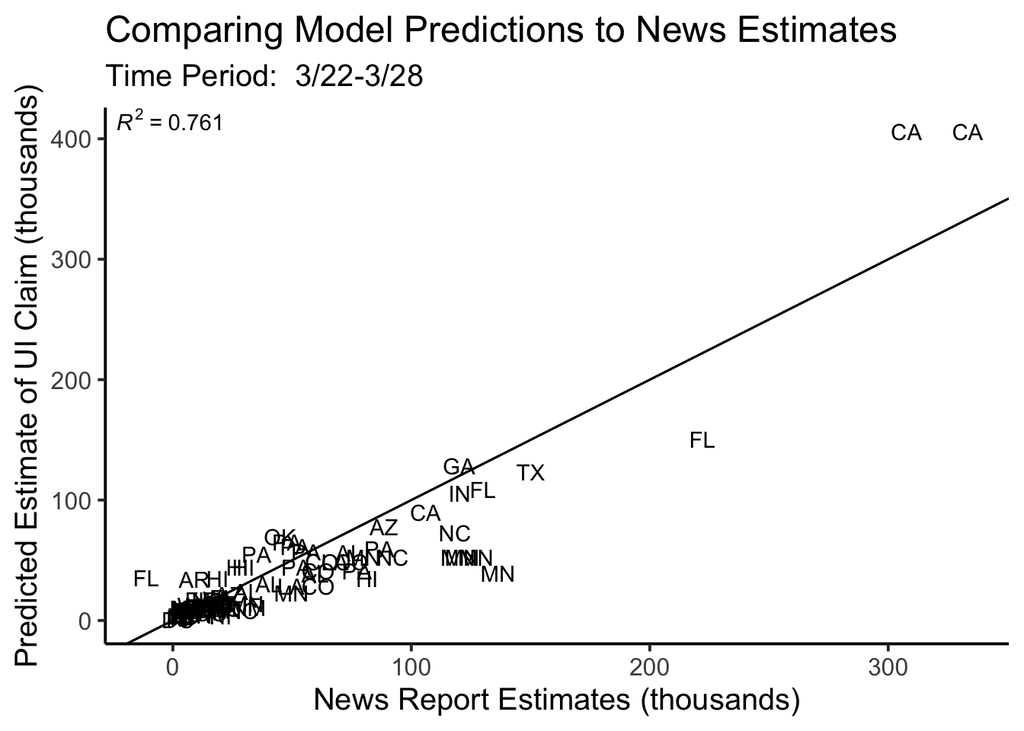

We also compare to advance UI claims reports:

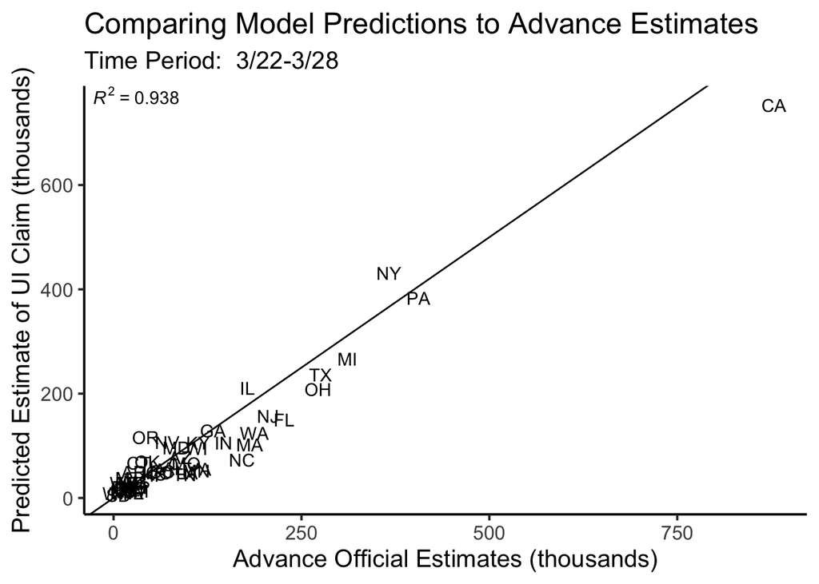

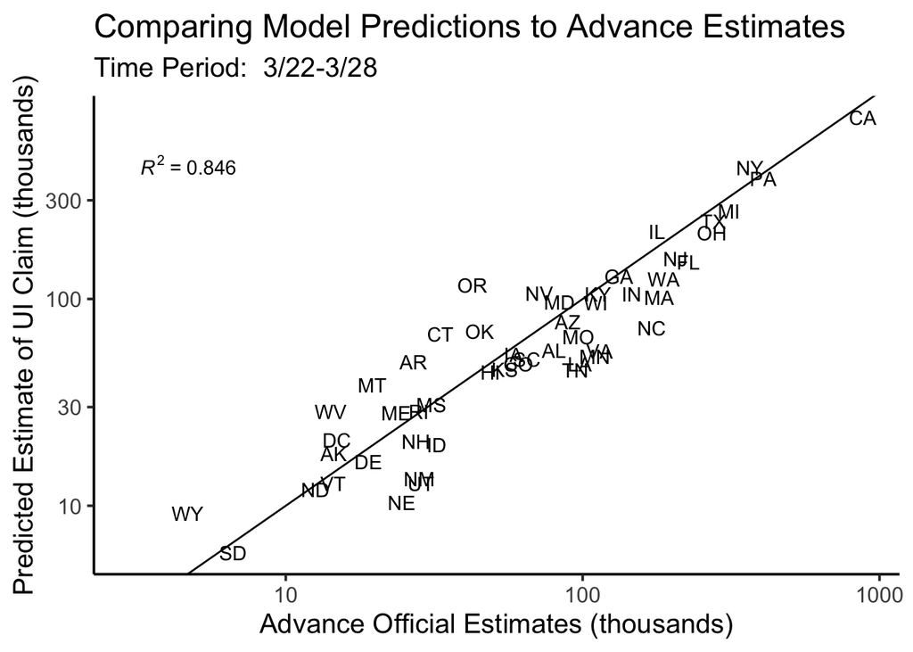

Nationally, search intensity on Sunday, March 22, the first day that included in the WE0328 report, was about 5 times higher than the prior Sunday and Monday, March 23 was 2.5 times higher than the prior Monday. Interest continued to be high throughout the week, suggesting significant new UI activity would occur. Combining the growth in search interest with the estimated information with our model implied a prediction of 5.7 million UI claims, with a 95% CI of 5.2 million and 6.2 million for WE0328 and subsequent weeks. We report the model’s not-seasonally-adjusted predictions as well.

| Week | Not Seasonally Adjusted Predicted UI Claims (millions) | Not Seasonally Adjusted 95% Confidence Interval Lower Bound | Not Seasonally Adjusted 95% Confidence Interval Upper Bound | Seasonally Adjusted Predicted UI Claims (millions) | Seasonally Adjusted 95% Confidence Interval Lower Bound | Seasonally Adjusted 95% Confidence Interval Upper Bound |
| --- | --- | --- | --- | --- | --- | --- |
| 03/15-03/21 | 4.0 | 3.6 | 4.4 | 4.6 | 4.1 | 5.0 |
| 03/22-03/28 | 5.0 | 4.6 | 5.4 | 5.7 | 5.2 | 6.2 |
| 03/29-04/04 | 5.1 | 4.6 | 5.5 | 5.4 | 4.9 | 5.9 |
| 04/05-04/11 | 4.1 | 3.7 | 4.4 | 4.3 | 3.9 | 4.7 |
| 04/12-04/18 | 3.8 | 3.5 | 4.2 | 4.0 | 3.6 | 4.4 |
| 04/19-04/25 | 3.4 | 3.1 | 3.8 | 3.8 | 3.4 | 4.2 |
| 04/26-04/27 | 3.3 | 3.0 | 3.7 | 3.7 | 3.3 | 4.1 |